# Week 5: Linear models v20260302e

**Content:**

- Part 1: Linear Regression in 1D
- Part 2: Fitting non-linear data with Linear Regression in 1D
- Part 3: Linear regression on the Wine dataset
- Part 4: Logistic regression (from first principles) on the Wine dataset
- Assignment 5: Linear models on the Whisky dataset

**Objective:** become familiar with fitting linear regression models in Python.

```python
import numpy as np
import pandas as pd

import matplotlib.pyplot as plt
import sklearn.linear_model as lm
import seaborn as sns

# Plotting style
sns.set_style('darkgrid')
sns.set_theme(font_scale=1.)
```

## Introduction

Regression is widely used in data mining and machine learning for predicting an output (dependent variable) for a data object given its attributes. Regression can be defined as the task of learning a target function that maps a set of attributes onto an output. In other words, regression is a *supervised learning* techniques that generalizes from known examples.

We will initially consider a linear regression problem with the goal of modeling the outputs, $\boldsymbol{y}=\left[y_1, y_2, \dots, y_N\right]^\top$, based on a single attribute for each of $N$ data objects, $\boldsymbol{X}=\left[x_1, x_2, \dots, x_N\right]^\top$. To do this, we consider the model $$ \begin{equation*} y_n=w_0+w_1x_n+\epsilon_n, \end{equation*} $$ where $\epsilon_n$ is residual noise, $w_0$ a constant offset and $w_1$ the linear coefficient for $x_n$. We can write an equation for the target $y_n$ for each data object as $$ \begin{aligned} y_1&=w_0+w_1x_1+\epsilon_1\\ y_2&=w_0+w_1x_2+\epsilon_2\\ &\qquad \qquad \vdots \\ y_N&=w_0+w_1x_N+\epsilon_N.\\ \end{aligned} $$

We can think of the $n$'th equation as a vector product between the fixed true weight vector, $\boldsymbol{w} = \left[ w_0 , w_1 \right]^\top$, and the modified data point, $\tilde{\boldsymbol{x}}_n = \left [ 1, x_n \right ]^\top$. We can collect all modified data points in the matrix $\tilde{\boldsymbol{X}} = \left [ \bf{1} , \boldsymbol{x} \right ]$ where $\mathbf{1} = \left[ 1, 1, \dots , 1 \right]^\top$ is a vector of $N$ ones which allows us to compactly write the equations in matrix-vector form as $$ \begin{equation*} \boldsymbol{y} = \tilde{\boldsymbol{X}} \boldsymbol{w} + \boldsymbol{\epsilon} \end{equation*} $$

## Part 1: Linear Regression in 1D

First, we will fit a simple linear regression model to 1-dimensional data generated by the following relation: $$ y_n = -0.5 + 0.01 \cdot x_n + \epsilon_n, \quad \epsilon_n \sim \mathcal{N}\left(0, 0.1\right) $$

Each of the $n$ attribute values $x_n$ should be set to $x_1\!\!=\!0, x_2\!\!=\!1, x_3\!\!=\!2, \dots, x_N\!\!=\!N-1$ and $\epsilon_n$ describes the observation noise.

**Task 1.1:** Create a function `generate_data` that returns $N$ samples of this 1D dataset in the range $x\in[0,N-1]$. Plot the generated samples and the true noise-free function.

> *Hint*: You can use `np.arange` to make a sequence of integers.

> *Hint*: You can generate random numbers from a univariate Normal distribution using the function `np.random.normal`.

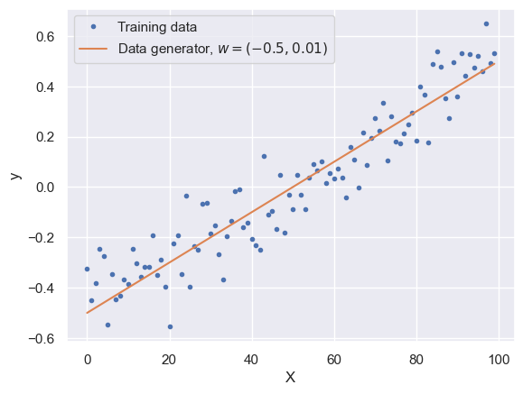

```python
def generate_data(w=(-0.5, 0.01), N=100, eps_std=0.1, seed=0):
    np.random.seed(seed)

    ### BEGIN SOLUTION
    X = np.arange(N).reshape(-1, 1)                             # N attribute values from 0 to N-1
    eps = np.random.normal(0, eps_std, N).reshape(-1, 1) # noise from normal distribution
    y = (w[0] + w[1] * X + eps).reshape(-1, 1)                  # generated outputs based on the linear relation
    ### END SOLUTION

    return X, y, eps

# Plotting the generated data
N = 100                     # number of data objects
eps_std = 0.1               # observation noise parameter
w = (-0.5, 0.01)            # parameters of the linear relation

# Generate data with your function
X, y, eps = generate_data(eps_std=eps_std, w=w, N=N, seed=0)

# Get the true output values without noise
### BEGIN SOLUTION
y_true = w[0] + w[1] * X

# Or alternatively:
# y_true = y - eps
### END SOLUTION

# Plot original data and the model output
f = plt.figure()
plt.plot(X, y, ".", label="Training data")
plt.plot(X, y_true, "-", label=f"Data generator, $w={w}$")
plt.xlabel("X")
plt.ylabel("y")
plt.legend()
plt.show()
```

Generally, in real life problems, we do not know the true coefficients generating the data. Our goal is therefore to *estimate* the coefficients, $w_0$ and $w_1$, from the data observations under the assumption that the data-generating process is linear. For doing so, we minimise the least squares error function, i.e. $$ \begin{equation*} \boldsymbol{w}^\ast = \begin{bmatrix} w_0^\ast \\ w_1^\ast \end{bmatrix} = \arg\min_{w_0, w_1} \sum_{n=1}^N \left(y_n-\left(w_0+w_1x_n\right)\right)^2=\arg\min_{w_0, w_1} \left\|\boldsymbol{y} - \tilde{\boldsymbol{X}} \boldsymbol{w} \right\|_F^2. \end{equation*} $$ Solving this optimization problem, the optimal parameter estimate has the closed-form expression $$ \boldsymbol{w}^\ast = \left(\tilde{\boldsymbol{X}}^\top \tilde{\boldsymbol{X}}\right)^{-1} \tilde{\boldsymbol{X}}^\top \boldsymbol{y} $$ Based on the estimated parameters we can predict the value of an unobserved output $y^\ast$ from an observed measurement $x^*$ as $$ \begin{equation*} y_\ast = \left[\begin{array}{c} 1 & x_\ast \end{array} \right] \left[ \begin{array}{c} w^\ast_0 \\ w^\ast_1\end{array} \right] = \boldsymbol{x}_\ast^\top \tilde{\boldsymbol{w}}^\ast \end{equation*} $$

**Task 1.2:** Fit a linear model to the data points and plot the estimated model on top of the data and true function.

> *Hint*: First create `X_tilde` by adding to `X` a column of ones. This allows you to compute `w_star`, by using `np.linalg.solve`. Finally, `y_est`is obtained by multiplying `X_tilde`and `w_star`.

> **Optional:** Try using sklearn's `sklearn.linear_model.LinearRegression` as an alternative. Do the two methods agree?

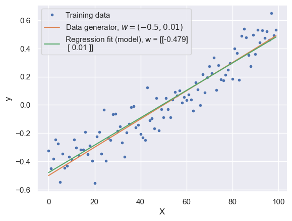

```python
### BEGIN SOLUTION
X_tilde = np.power(X, range(0,  2))

# Fit linear regression using normal equation
w_star = np.linalg.solve(X_tilde.T @ X_tilde, X_tilde.T @ y)

# Predicted values using the estimated model
y_est = X_tilde @ w_star
### END SOLUTION

# Plotting the generated data along with the true data generator and the estimated model
f = plt.figure()
plt.plot(X, y, ".")
plt.plot(X, y_true, "-")
plt.plot(X, y_est, "-")
plt.xlabel("X")
plt.ylabel("y")
plt.legend(["Training data", f"Data generator, $w={w}$", f"Regression fit (model), w = {np.round(w_star,3)}"])
plt.show()
```

**Task 1.3:** Explain how the model estimates the parameters, $w_0$ and $w_1$, from the data you have generated.

- *Answer:*

**Task 1.4:** Explain why the estimated parameters are close, but not exactly equal, to the parameters used to generate the data.

- *Answer:*

**Task 1.5:** Go back and play around with the number of data samples, `N`, and the noise variance, `eps_std`. How can you get the estimated model parameters closer to the actual parameters used to generate the data?

## Part 2: Fitting non-linear data with a linear model - linear Regression in 1D

Sometimes there are more complex relationships between the attributes and output. In order to capture more complex relationships we can include attributes that are specified transformations of existing attributes such as $\sqrt{x}$, $\log{(x)}$, $x^2$ and $x^3$.

We will presently consider the model

\begin{equation*} y_n = w_0 + \sum_{k=1}^{K} w_k x_n^k + \epsilon_n. \end{equation*}

You can see this as a generalisation of Part 1, where $K=1$.

The above model can again be written for all $N$ observations simultaneously in terms of vectors and matrices, i.e.

$$ \boldsymbol{y} = \left[\boldsymbol{1}\ \boldsymbol{x}^1\ \boldsymbol{x}^2\ \dots\ \boldsymbol{x}^{K}\right] \begin{bmatrix} w_0 \\ w_1 \\ w_2 \\ \vdots \\ w_{K} \end{bmatrix} + \boldsymbol{\epsilon} = \left[\boldsymbol{1}\ \boldsymbol{X}\right] \boldsymbol{w} + \boldsymbol{\epsilon} $$

where $\boldsymbol{x}^{k}=\left[ x_1^{k}, x_2^{k}, \dots, x_N^{k}\right]^\top$.

**Task 2.1:** Create a function `generate_data` that returns $N$ samples of this dataset in the range $x\in[-2,2]$. The function should allow you to specify how many $K$ terms to include (squared, cubed, etc.) for generating the data.

> *Hint*: You can use `np.linspace()` to make a sequence of real numbers.

> *Hint*: See the function `np.power()` that can raise the content of a vector/matrix to a specified order.

**Task 2.2:** Generate $N=50$ samples with $\boldsymbol{w} = -\begin{bmatrix}-0.9 & -0.9^2 & \dots & -0.9^{K+1}\end{bmatrix}^\top$ for $K=5$. Plot the generated samples and the true function in the range $x\in[-2,2]$ with a higher resolution on the x-axis.

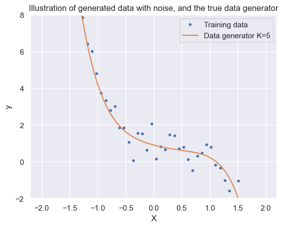

```python
def generate_polynomial_data(w, K_data, eps_std, seed=0):
    np.random.seed(seed)

    ### BEGIN SOLUTION

    # Generate dataset (with noise)
    X = np.linspace(-2, 2, N).reshape(-1, 1)
    # Apply polynomial transformation to X
    X_transformed = np.power(X, range(1, K_data + 1))

    # Generate noise
    eps = eps_std * np.random.randn(N)

    # Generate outputs based on the linear relation
    y = w[0] + X_transformed @ w[1:] + eps
    ### END SOLUTION

    return X, y, eps


# Parameters
N = 50                      # no of data objects to train a model
K_data = 5                  # no of terms for data generator
eps_std = 0.5  # noise parameters

# Define the true parameter vector
### BEGIN SOLUTION
w_true = -np.power(-0.9, range(1, K_data + 2))
### END SOLUTION

# Generate data with your function
X, y, eps = generate_polynomial_data(w=w_true, K_data=K_data, eps_std=eps_std, seed=0)

# Sampling 1000 points to visualize the true data and model
N_est = 1000
X_est = np.linspace(-2, 2, 1000).reshape(-1, 1)

# Define the true data generator function, y_true (assuming no noise)
### BEGIN SOLUTION
Xde = np.power(X_est, range(1, K_data + 1))
y_true = w_true[0] + Xde @ w_true[1:]
### END SOLUTION

# Plot original data and the model output
f = plt.figure()
plt.title("Illustration of generated data with noise, and the true data generator")
plt.plot(X, y, ".", label="Training data")
plt.plot(X_est, y_true, "-", label=f"Data generator K={K_data}")
plt.xlabel("X")
plt.ylabel("y")
plt.ylim(-2, 8)
plt.legend()
plt.show()
```

We now want to fit a model with polynomial terms of order $K_{m}$ to the data generated above. The models output can be formulated as $$ \begin{equation*} y_n = w^\ast_0 + \sum_{k=1}^{K_m} w^\ast_k x_n^k \qquad \text{or} \qquad \boldsymbol{y} = \tilde{\boldsymbol{X}} \boldsymbol{w}^\ast \end{equation*} $$ for $N$ observations where $\tilde{\boldsymbol{X}} = \left[\boldsymbol{1}, \boldsymbol{x}, \boldsymbol{x}^2, \dots, \boldsymbol{x}^{K_m} \right]$. Remark the difference between the order of the model, $K_m$, and the order of the data, $K$. This model can fit non-linear trend of the data but is *still linearly dependent on the model weights*. The overall formulation is therefore exactly the same as before for which we know how to compute the coefficients.

**Task 2.2:** Estimate the model parameters for a model with polynomial order of $K_{m} = 3$. Plot the estimated model on top of the generated data samples and true model.

> *Hint*: Use `X` to create a matrix `X_tilde` and use it for model fitting.

> *Hint*: Use `X_est`to create a matrix `X_est_tilde` and use it for model prediction.

> *Hint*: Consider the formula $$w^*=(\tilde{\boldsymbol{X}}^\top\tilde{\boldsymbol{X}})^{-1}\tilde{\boldsymbol{X}}y,$$ which can be found in Chapter 8 of your textbook.

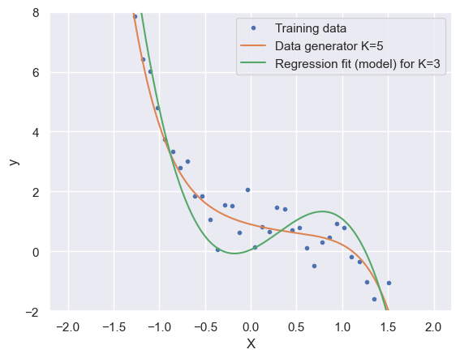

```
Estimated parameters: [ 0.05584024  1.32478325  2.8621672  -3.16053618]
```

```python
K_model = 3

# Fit the model with polynomial features up to degree K_model and estimate the outputs as y_est
### BEGIN SOLUTION

# Create polynomial features for training
X_tilde = np.power(X, range(0, K_model + 1))

# Fit linear regression using normal equation
w_star = np.linalg.inv(X_tilde.T @ X_tilde) @ ((X_tilde.T @ y).reshape(-1, 1))

# Create polynomial features for prediction (evaluation set)
X_est_tilde = np.power(X_est, range(0, K_model + 1))

# Predict
y_est = X_est_tilde @ w_star
### END SOLUTION

# Plot original data and the model output
f = plt.figure()
plt.plot(X, y, ".", label = "Training data")
plt.plot(X_est, y_true, "-", label = f"Data generator K={K_data}")
plt.plot(X_est, y_est, "-", label = f"Regression fit (model) for K={K_model}")
plt.xlabel("X")
plt.ylabel("y")
plt.ylim(-2, 8)
plt.legend()
plt.show()

print(f"Estimated parameters: {w_star.flatten()}")
```

**Task 2.3:** Play around with the parameters of the experiment and reflect on how they impact the model fit.

- How well does the model fit the data points? How well does the model fit the true underlying function?
- What happens when fitting a model with more higher order terms, e.g. $K_m=10$ or $K_m=25$? Do you see any potential problems when setting $K_m$ too high?
- Try increasing the number of samples to $N=1000$ while keeping the $K_m=25$. How does this impact the model fit? How did this impact the potential problem?

## Part 3: Linear regression on the Wine dataset

We will now take a look at the wine data set and attempt to predict the alcohol content (given in percentage) using linear regression. The linear regression model we consider is

$$ \begin{equation*} y_n=w_0+\sum_k w_kx_{n,k}+\epsilon_n, \end{equation*} $$ where $y_n$ is the observed alcohol content, $\epsilon_n$ the model residual, $w_k$ the value of the estimated model coefficient for the $k^{th}$ attribute, whereas $x_{n,k}$ denotes the $n^{th}$ observation of the $k^{th}$ attribute. As such, $x_{2,1}$ denotes the second observation of the first attribute (Fixed acidity) and $x_{5,2}$ the fifth observation of the second attribute (Volatile acidity).

Say we expect volatide acidity (VA) to be around $0-2 \textrm{g}/\textrm{dm}^3$, density (D) to be close to $1 \textrm{g}/\textrm{cm}^3$, and alcohol percentage (AP) to be somewhere between $5-20\% \textrm{vol}$. We can use this knowledge to define wines with VA > 2, D > 1 and AP > 20 as outliers.

**Task 3.1:** Load the Wine dataset in Pandas from the accompanied data-folder and take a look at the data structure. Remove the `"Quality score (0-10)"`-column as well as potential outliers.

> *Hint:* Use `pd.read_csv`, `df.drop()` and `df.head()`

> *Hint:* Pandas allows for logical conditions like `(df['Alcohol'] > 20)` to identify rows with outliers. Combine multiple conditions using the `|` operator (logical OR), and wrap each condition in parentheses. To remove the outliers, consider using the `~` operator to invert the filter.

```python
# Load the wine dataset in pandas DataFrame
### BEGIN SOLUTION

df = pd.read_csv('data/wine.csv')
df = df.drop(columns=['Quality score (0-10)'])

# Filter outliers based on the defined rules
df = df[~((df['Volatile acidity'] > 2) | (df['Density'] > 1) | (df['Alcohol'] > 20))]
### END SOLUTION

print(df.shape)
df.head()
```

```
(6304, 12)
```

|  | Fixed acidity | Volatile acidity | Citric acid | Residual sugar | Chlorides | Free sulfur dioxide | Total sulfur dioxide | Density | pH | Sulphates | Alcohol | Color |
| --- | --- | --- | --- | --- | --- | --- | --- | --- | --- | --- | --- | --- |
| 0 | 7.4 | 0.70 | 0.00 | 1.9 | 0.076 | 11.0 | 34.0 | 0.9978 | 3.51 | 0.56 | 9.4 | Red |
| 1 | 7.8 | 0.88 | 0.00 | 2.6 | 0.098 | 25.0 | 67.0 | 0.9968 | 3.20 | 0.68 | 9.8 | Red |
| 2 | 7.8 | 0.76 | 0.04 | 2.3 | 0.092 | 15.0 | 54.0 | 0.9970 | 3.26 | 0.65 | 9.8 | Red |
| 3 | 11.2 | 0.28 | 0.56 | 1.9 | 0.075 | 17.0 | 60.0 | 0.9980 | 3.16 | 0.58 | 9.8 | Red |
| 4 | 7.4 | 0.70 | 0.00 | 1.9 | 0.076 | 11.0 | 34.0 | 0.9978 | 3.51 | 0.56 | 9.4 | Red |

Originally the dataset is used for binary classification on red vs. white wines, which we will also be doing with logistic regression in Part 4. For now we will consider the `Alcohol` content as our target attribute and perform a linear regression using the remaining attributes.

**Task 3.3:** Pick the correct columns of the dataframe, to construct your `X` and `y` matrices containing input attributes and target attributes for the task.

```python
### BEGIN SOLUTION
X = df.drop(columns=['Alcohol', 'Color'])
y = df['Alcohol']
### END SOLUTION
```

**Task 3.4:** Fit a linear model of the data points and calculate the residuals. Collect the estimated parameters in a vector (as previously) and plot the estimated model.

> *Hint:* You can use the formula from Task 2.2 to compute $w^*$.

> *Hint:* Which values `y_est` does the model predict for $X$? The residual will be the difference between `y_est`and the true `y`.

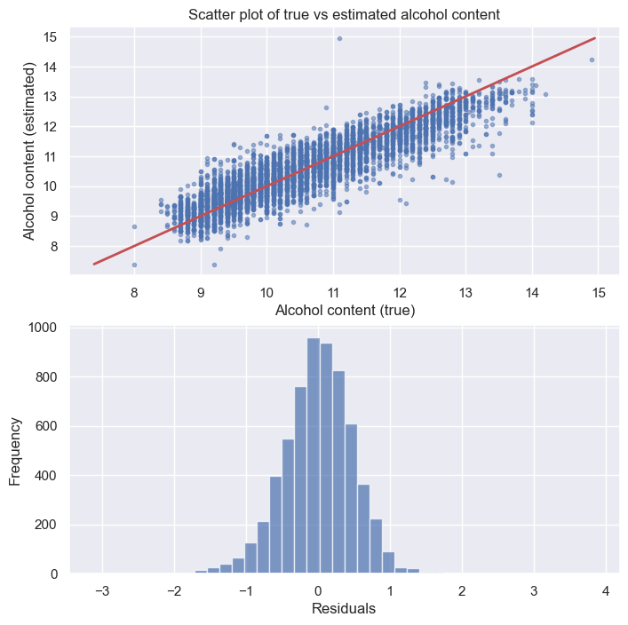

```
Estimated parameters:
Fixed acidity: 622.356
Volatile acidity: 0.584
Citric acid: 1.319
Residual sugar: 0.322
Chlorides: 0.208
Free sulfur dioxide: 0.405
Total sulfur dioxide: 0.001
Density: -0.005
pH: -631.055
Sulphates: 2.981

MSE: 0.249
```

```python
# Fit regression model to the wine dataset
### BEGIN SOLUTION
X_tilde = np.column_stack([np.ones(len(X)), X])  # Add intercept term

#closed form solution as in previous exercise
w_star = np.linalg.solve(X_tilde.T @ X_tilde, X_tilde.T @ y)
# Predict alcohol content

y_est = X_tilde @ w_star

# Calculate residuals
residual = y_est - y

### END SOLUTION

# Display scatter plot and histogram of residuals
fig, axs = plt.subplots(2, 1, figsize=(8, 8))
axs[0].scatter(y, y_est, marker='.', alpha=0.5)
# Add x = y line
min_val = min(y.min(), y_est.min())
max_val = max(y.max(), y_est.max())
axs[0].plot([min_val, max_val], [min_val, max_val], 'r-', linewidth=2)

axs[0].set_xlabel("Alcohol content (true)")
axs[0].set_ylabel("Alcohol content (estimated)")
axs[0].set_title("Scatter plot of true vs estimated alcohol content")
axs[1].hist(residual, bins=40, alpha=0.7)
axs[1].set_xlabel("Residuals")
axs[1].set_ylabel("Frequency")
plt.show()

# Estimated parameters, and their attribute names
print("\033[1mEstimated parameters:\033[0;0m")  # Bold text for emphasis
for i, name in enumerate(X.columns):
    print(f"{name}: {w_star[i].item():.3f}")

print(f"\nMSE: {np.mean(residual**2):.3f}")
```

**Task 3.5** Explain what the visualisations tell you about the accuracy of the prediction.

- *Answer:*

**Task 3.6:** Argue from the estimated parameters of the linear regression model that wines with higher alcohol content in general have lower density. Consider verifying it with a small code example: you can take a random wine from the dataset and call it `example`. You then create 100 copies and let the density value vary between `X['Density'].min()`and `X['Density'].max()`. Using your model, you now predict the alcohol value for these new samples.

- *Answer:*

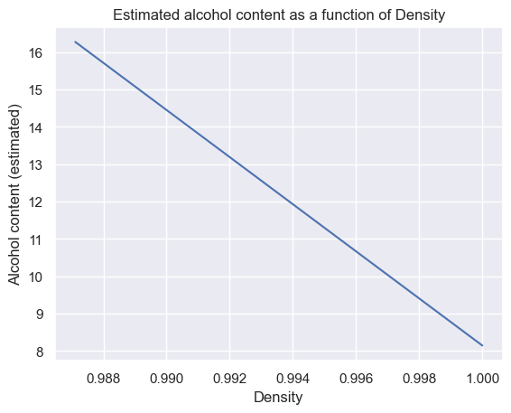

```python
example = X.iloc[0, :]
# Create a dataframe with many copies of the example
example = pd.DataFrame([example] * 100, columns=X.columns)
# Define a realistic density range
density_vals = np.linspace(X['Density'].min(), X['Density'].max(), 100)
# replace the dummy density attribute with the range
example['Density'] = density_vals.flatten()

### BEGIN SOLUTION
# Can be inferred directly from the estimated parameter of Density being negative
# But we can also visualize it, by taking a random Wine from the dataset, and varying its density attribute.
example = np.column_stack([np.ones(len(example)), example])
alc_predict  = example @ w_star

### END SOLUTION
# Plot the estimated alcohol content as a function of Density
fig = plt.figure()
plt.title("Estimated alcohol content as a function of Density")
plt.plot(density_vals, alc_predict)
plt.xlabel("Density")
plt.ylabel("Alcohol content (estimated)")
plt.show()
```

**Task 3.7:** Go back to where you defined your data matrix `X`. How does the following affect the performance of your linear regression model (try modifiying you code to do this)?

- Standardization of the input attributes.
- Standardization of the target attribute.
- Adding a new feature that is pure noise.
- Adding a new feature that is very similar to an existing one. E.g. do `X['new-pH'] = X['pH'] + 0.01 * np.random.randn(X.shape[0])`

As we saw in Part 2, specific data attributes can have a non-linear relationship with the output and we need to consider if specific transformations of attributes can capture such non-linear patterns effectively. For determining if there are any obvious transformations, we take a closer look at the wine data set.

**Task 3.8:** Create a figure with subplots that shows each attribute against the alcohol content as scatter plots. Create a similar figure showing each attribute against the model residual.

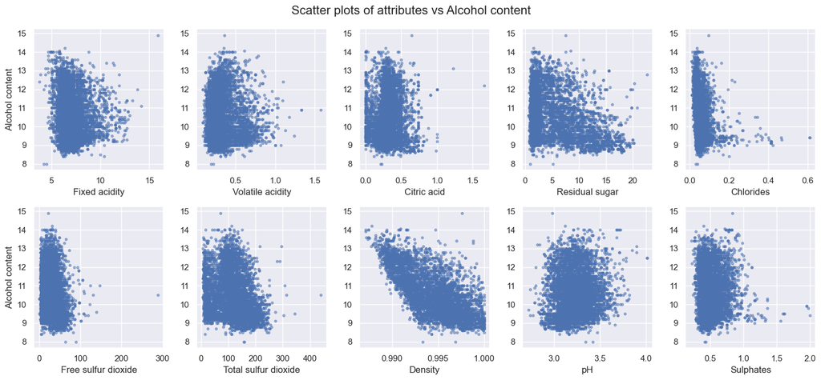

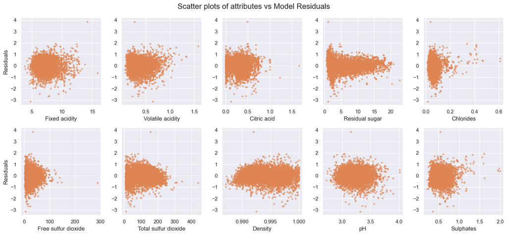

```python
### BEGIN SOLUTION
# Plot a scatter plot with all attributes in X against the alcohol content
fig, axs = plt.subplots(2, len(X.columns) // 2, figsize=(15, 7))
fig.suptitle("Scatter plots of attributes vs Alcohol content", fontsize=16)
for i, attribute in enumerate(X.columns):
    # Determine the row and column for the subplot
    row, col = divmod(i, len(X.columns) // 2)
    # Plot the scatter plot
    axs[row, col].scatter(X[attribute], y, marker='.', alpha=0.5)
    axs[row, col].set_xlabel(attribute)
    # Add y label only to the first column
    if col == 0:
        axs[row, col].set_ylabel("Alcohol content")
plt.tight_layout()
plt.show()

# Plot a scatter plot with all attributes in X against the model residuals
fig, axs = plt.subplots(2, len(X.columns) // 2, figsize=(15, 7))
fig.suptitle("Scatter plots of attributes vs Model Residuals", fontsize=16)
for i, attribute in enumerate(X.columns):
    # Determine the row and column for the subplot
    row, col = divmod(i, len(X.columns) // 2)
    # Plot the scatter plot
    residual = y_est.flatten() - y  # Calculate residuals
    axs[row, col].scatter(X[attribute], residual, marker='.', alpha=0.5, color='C1')
    axs[row, col].set_xlabel(attribute)
    # Add y label only to the first column
    if col == 0:
        axs[row, col].set_ylabel("Residuals")
plt.tight_layout()
plt.show()
### END SOLUTION
```

**Task 3.9:** Argue what transformations could be useful for making the linear assumption of the regression model more appropriate. Construct a new data matrix `X_tilde` and fit a linear regression model to the transformed wine data. Compute the mean-squared error (MSE) and plot each transformed attribute vs. the residual as scatter plots.

> *Hint*: Feel free to iterate - how low can you get the MSE?

> *Hint*: Plots of attributes versus the model residuals can help reveal if there is structure in the output that can be explained by transformations of the attributes.

> *Hint*: You can use `np.log()`, `np.power()`, `np.multiply()`, etc. on appropriate columns of data matrix.

> *Hint*: The `np.bmat()` function is useful to concatenate matrices and/or vectors.

```
MSE: 0.23536901978727087
```

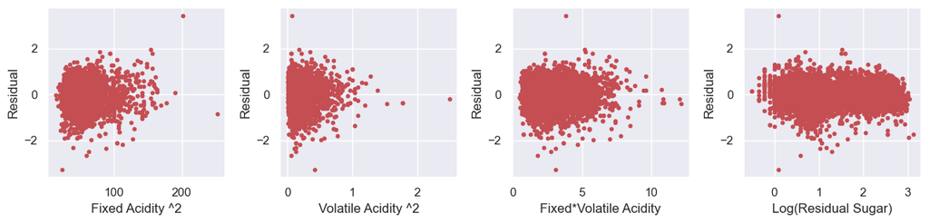

```python
### BEGIN SOLUTION
# Construct additional attributes
Xfa2 = np.power(df['Fixed acidity'], 2).values.reshape(-1, 1)
Xva2 = np.power(df['Volatile acidity'], 2).values.reshape(-1, 1)
Xfava = (df['Fixed acidity'] * df['Volatile acidity']).values.reshape(-1, 1)
Xrslog = np.log(df['Residual sugar']).values.reshape(-1, 1)

# Update the feature matrix to include additional attributes
X_tilde = np.asarray(np.bmat("X, Xfa2, Xva2, Xfava, Xrslog"))
X_tilde = np.column_stack([np.ones(len(X_tilde)), X_tilde])  # Add intercept term

#closed form solution as in previous exercise
w_star = np.linalg.solve(X_tilde.T @ X_tilde, X_tilde.T @ y)

# Predict alcohol content
y_est = X_tilde @ w_star
residual = y_est - y

# Display plots
fig, axs = plt.subplots(1, 4, figsize=(12, 3))
axs[0].scatter(Xfa2, residual, marker='.', color='r')
axs[0].set_xlabel("Fixed Acidity ^2")
axs[0].set_ylabel("Residual")
axs[1].scatter(Xva2, residual, marker='.', color='r')
axs[1].set_xlabel("Volatile Acidity ^2")
axs[1].set_ylabel("Residual")
axs[2].scatter(Xfava, residual, marker='.', color='r')
axs[2].set_xlabel("Fixed*Volatile Acidity")
axs[2].set_ylabel("Residual")
axs[3].scatter(Xrslog, residual, marker='.', color='r')
axs[3].set_xlabel("Log(Residual Sugar)")
axs[3].set_ylabel("Residual")
plt.tight_layout()

print("MSE:", np.mean(residual**2))
### END SOLUTION
```

## Part 4: Logistic regression on the Wine dataset

Until now we have discussed the most simple linear model based on the squared error cost function. In the generalized linear model, we can also use other loss/cost functions as well as non-linear link functions.

It can be very useful to limit the possible outputs to the range $(0,1)$ if the outputs we wish to predict are binary. Predicting binary outputs is what we have previously referred to as binary classification and generalized linear models can thus both be used for regression and classification.

Classification with a likelihood function based on the Bernoulli distrbution and logistic link function is called *logistic regression* (for more information [see here](https://en.wikipedia.org/wiki/Logistic_regression)). We will return to the wine data and predict the type of wine using logistic regression. The model we consider is $$ p(y_n = 1 \mid \mathbf{x}_n, \mathbf{w})=\sigma\left(w_0+\sum_k w_k x_{n, k}\right)=\sigma\left( \mathbf{w}^T\mathbf{x} \right) $$ where $p(y_n = 1 \mid \mathbf{x}_n, \mathbf{w})$ is the likelihood of observing and outcome $y=1$ where we encode the of wine with 0 and 1 (Red: $y_n=1$ and White: $y_n=0$) given the model. We will say that a wine is Red with probability $\hat p_n$ and White with probability $1-\hat p_n$. where $\hat p_n=\sigma(w_0+\sum_k w_k x_{n,k})$.

**Task 4.2:** Construct the data matrices `X` and `y` so that they are suitable for solving the binary classification problem.

> *Hint:* All you need to do here add the bias term to the data matrix; everything else is given.

```python
# Construct X and y for the classification problem, we apply the same filtering as before
df = pd.read_csv('data/wine.csv') # we load the data
df = df[~((df['Volatile acidity'] > 2) | (df['Density'] > 1) | (df['Alcohol'] > 20))] # filter
X = df.drop(columns=['Color','Quality score (0-10)']) # let's not use the quality score
y = df['Color'].values

# We count the number of types
n_red = (y == "Red").sum()
n_white = (y == "White").sum()
n_total = len(y)
print(f"# Red:   {n_red}")
print(f"# White: {n_white}")
print(f"# Total: {n_total}")

# Encode Red as 0 and White as 1
y = np.array([1 if val == 'Red' else 0 for val in y])
y = y.reshape(-1, 1)

# Std. the dataset (note we will need these values later!)
mu = X.mean(axis=0)
sig = X.std(axis=0, ddof=0)
X_std = (X - mu) / sig

# Add bias term and save as X_tilde
### BEGIN SOLUTION
X_tilde = np.column_stack([np.ones(len(X)), X_std])
### END SOLUTION

# Print (subset) to check everything look fine
print(f"\nX_tilde = {np.array2string(X_tilde)}")
print(f"\ny = {np.array2string(y)}")
```

```
# Red:   1517
# White: 4787
# Total: 6304

X_tilde = [[ 1.          0.19891892  2.22460571 ...  1.80533147  0.21116188
  -0.93355658]
 [ 1.          0.53317004  3.33046426 ... -0.12336623  1.02363193
  -0.5971095 ]
 [ 1.          0.53317004  2.59322523 ...  0.2499301   0.82051442
  -0.5971095 ]
 ...
 [ 1.         -0.55314611 -0.60147723 ... -1.42990337 -0.4658965
  -0.93355658]
 [ 1.         -1.38877391 -0.29429431 ...  0.74765854 -1.0075432
   1.92624357]
 [ 1.         -0.97096001 -0.78578699 ...  0.2499301  -1.41377823
   1.08512588]]

y = [[1]
 [1]
 [1]
 ...
 [0]
 [0]
 [0]]
```

To do so, we will write a set of functions which finds the optimal parameter `w_star`thorugh gradient descent and predict the probability of y, $p(y_n\mid \mathbf{x_n}, \mathbf{w})$.

Recall, the setup is as follows: $ f_n=f({\boldsymbol{x}}_n;\boldsymbol{w})=\boldsymbol{w}^\top {\boldsymbol{x}}_n, \hat p_n=p(y_n=1 \mid \mathbf{x_n}, \mathbf{w})=\sigma(f_n),$ and $\sigma(z)=\frac{1}{1+e^{-z}}$.

> *Rationale*: Of course these functions are already implemented in e.g. sklearn and many other places, however we want you do know what these "toolbox" functions actually do, hence we provide the details here. You may wish to get you TA to explain the details but understanding how we get to the gradient is **not** part of the curricilum or exam.

**Tasks 4.3.1** Complete the function `my_function` that computes and return the function f evaluated at $\mathbf{x}$, i..e, value $f( \boldsymbol{x}; \boldsymbol{w})=\boldsymbol{w}^T\boldsymbol{x}$. The function must be able to compute $f$ for a matrix $\boldsymbol{X}$ and return a vector, `f_val`, as output.

```python
def my_function(X, w):
    ### BEGIN SOLUTION
    f_val = X @ w
    ### END SOLUTION
    return f_val
```

**Task 4.3.2.** Complete the sigmoid function $\sigma(z) = \frac{1}{1 + e^{-z}}$. Save the output in `sigma`. We plot the function for you.

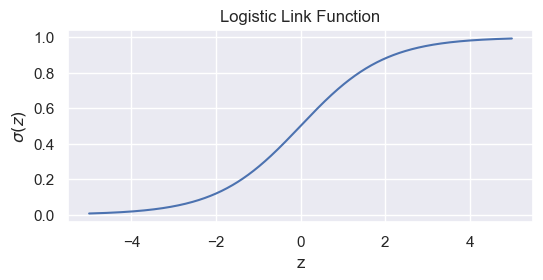

```python
def link_function_sigmoid(z):
    ### BEGIN SOLUTION
    sigma = 1 / (1 + np.exp(-z))
    ### END SOLUTION
    return sigma

# We plot how it looks like
zaxis = np.linspace(-5, 5, 1000).reshape(-1, 1)
fig = plt.figure(figsize=(6, 2.5))
plt.plot(zaxis, link_function_sigmoid(zaxis))
plt.xlabel("z")
plt.ylabel(r"$\sigma(z)$")
plt.title("Logistic Link Function")
plt.show()
```

**Task 4.3.3** Complete the function `p_y_given_w_and_x` that takes `X`, `w` and `y` as inputs and returns the probabilty of y given the observation.

> - Hint: Use the `link_function_sigmoid` and `my_function` functions from above. Save and return as `p`.

```python
def p_y_given_w_and_x(w, X, y):
    ### BEGIN SOLUTION
    p_y_is_one_given_x = link_function_sigmoid(my_function(X,w))
    p = y*p_y_is_one_given_x + (1-y)*(1-p_y_is_one_given_x)
    ### END SOLUTION
    return p
```

**Task 4.3.4** We will implement a loss function that computes the loss for a single data point, effectively the negative log-likelihood of an observation given the model. We have that for an individual observation the loss is the negative log-likelihood, i.e.,

$$e_n(\mathbf{w}) = - log\,p(y_n \mid \mathbf{x}_n, \mathbf{w})$$

Complete the `loss_lr_n` function below to compute $e_n(w)$, Save as `e_n`

> *Hint* You have implemented $p(y \mid \mathbf{x}, \mathbf{w})$ in `p_y_given_w_and_x`

```python
def loss_lr_n(w,x_n,y_n):
    ### BEGIN SOLUTION
    e_n = -np.log( p_y_given_w_and_x(w,x_n,y_n) )
    ### END SOLUTION
    return e_n
```

**Task 4.3.5** Complete the function that computes the loss for all training points $\small E(\mathbf{w}) = - \frac{1}{N} \sum_{n=1}^N log\, p(y_n \mid \mathbf{x}_n , \mathbf{w}) $

> *Note*: We some times write the loss as the binary cross-entropy $\small E(\mathbf{w})= -\frac{1}{N}\sum_{n=1}^{N}\left[y_n\log \hat p(y=1\mid \mathbf{x}_n) + (1-y_n)\log 1-\hat p(y=1\mid \mathbf{x}_n))\right].$ We have implemented the function by splitting the computation in two functions to clearly indicate what the likelihood is and what the loss is.

```python
def loss_lr(w,X,y):
    ### BEGIN SOLUTION
    es = loss_lr_n(w,X,y)
    e = np.sum(es) / X.shape[0]
    ### END SOLUTION
    return e
```

**Gradients of the loss function (optional, skip the first time around and go to the next task)**. We consider the gradient of the loss functio, i.e., how much does the loss change if we change the weights. This is quite math heavy and you are not expected to nessesarily understand everything except the conceptual meaning of what a gradient of a loss funciton is. If we consider the loss (derived from the likelihood) per observation which we need to optimize the the weights $\mathbf{\mathbf{w}}$: $e_n(\mathbf{w})= -\left>[y_n\log \hat p_n + (1-y_n)\log(1-\hat p_n)\right]$ and $E(\mathbf{w})=\frac{1}{N}\sum_{i=1}^N e_n(\mathbf{w}).$ where we use the shorthand notation $\hat p_n=p(y_n = 1 \mid \mathbf{x}_n)=\sigma( \mathbf{w}^T \mathbf{x}_n )$.

We exploit the chain rule and get $ \nabla_\mathbf{w} e_n(\mathbf{w})=\frac{\partial e_n}{\partial \hat p_n}\, \frac{\partial \hat p_n}{\partial f_n}\, \nabla_\mathbf{w} f_n. $ The individual terms can be extraced using basic calculus $$\small \frac{\partial e_n}{\partial \hat p_n} = -\left(y_n\frac{1}{\hat p_n}+(1-y_n)\frac{-1}{1-\hat p_n}\right) = -\frac{y_n}{\hat p_n}+\frac{1-y_n}{1-\hat p_n}. \qquad \frac{\partial \hat p_n}{\partial f_n} =\sigma'(f_n) =\sigma(f_n)\big(1-\sigma(f_n)\big) =\hat p_n(1-\hat p_n). \qquad \nabla_\mathbf{w} f_n=\nabla_\mathbf{w} (\mathbf{w}^\top \mathbf{x}_n)=\mathbf{x}_n. $$

We now get (and simplyfing a bit) $$ \nabla_\mathbf{w} e_n(\mathbf{w}) =\left(-\frac{y_n}{\hat p_n}+\frac{1-y_n}{1-\hat p_n}\right)\hat p_n(1-\hat p_n)\,\mathbf{x}_n. \qquad \left(-\frac{y_n}{\hat p_n}+\frac{1-y_n}{1-\hat p_n}\right)\hat p_n(1-\hat p_n) = -y_n(1-\hat p_n)+(1-y_n)\hat p_n = \hat p_n-y_n. $$

The final per-example gradient becomes $ \nabla_\mathbf{w} e_n(\mathbf{w})=(\hat p_n-y_n)\mathbf{x}_n =\Big(\sigma\!\big(f(\mathbf{x}_n;\mathbf{w})\big)-y_n\Big)\mathbf{x}_n. $ This is important, it tells you how much teh loss change if you change the weights based on a single observation. We are of course interested in how the loss changes across all the observations so we average the gradients accordingly (this is due to rules of differentiation) $$\small \nabla_\mathbf{w} E(\mathbf{w}) =\frac{1}{N}\sum_{i=1}^{N}\nabla_\mathbf{w} e_n(\mathbf{w}) =\frac{1}{N}\sum_{i=1}^{N}\Big(\sigma\!\big(f({\mathbf{x}}_n;\mathbf{w})\big)-y_n\Big)\mathbf{x}_n. $$

Of course we prefer the matrix form as it is more convinient: $$\small \nabla_\mathbf{w} E(\mathbf{w})=\frac{1}{N}{\mathbf{x}}^\top(\mathbf{\hat p} - \mathbf{y}). $$ where $\mathbf{y}$ are vectors of length N with the labeles and $\mathbf{\hat p}$ has the $p(y_n=1 \mid \mathbf{x}_n, \mathbf{w})$ values for all $N$ observations. **This is the equation you need to implement!**

**Task 4.3.6** Complete the function below that computes the loss and the gradient of wrt $\mathbf{w}$, i.e. $\nabla_\mathbf{w} E(\mathbf{w})=\frac{1}{N}{\boldsymbol{X}}^\top(\mathbf{\hat p} - \mathbf{y})$. Save $\nabla_\mathbf{w} E(\mathbf{w})$ in `g`.

```python
def loss_and_gradient_lr(w,X,y):
    N = X.shape[0]
    e = loss_lr(w,X,y)
    p_hat = p_y_given_w_and_x(w, X, np.ones( (N,1)) ) # to get p hat we compute p(y=1 | w, x) for all the x entries

    ### BEGIN SOLUTION
    g = (1/N) * X.T @ (p_hat - y)
    ### END SOLUTION

    return e, g
```

**Task 4.3.7** We now need an algorithm that uses the loss function and its gradient to iteratively move toward the best parameter vector $\boldsymbol{w}$. Intuitively, we "walk downhill" on the loss landscape—taking steps in the direction of steepest decrease—until we reach (a) a valley where the loss is minimal, or (b) a point where further improvement becomes negligible.

1. **Initialize parameters**: Choose an initial guess $\boldsymbol{w}^{(0)}$ (e.g., random values or zeros).
2. **Choose a learning rate** Pick a step size $\eta > 0$ (the learning rate).
3. **Iterate until convergence** (for $i = 0,1,2,\dots$)
   - 3.a) Compute the gradient:$\nabla_{\boldsymbol{w}} E\!\left(\boldsymbol{w}^{(i)}\right)$
   - 3.b) Update the parameters by stepping *against* the gradient: $\boldsymbol{w}^{(i+1)}=\boldsymbol{w}^{(i)}-\eta\,\nabla_{\boldsymbol{w}} E\!\left(\boldsymbol{w}^{(i)}\right)$ [this is the code you need to provide]
4. **Stopping criteria** Stop when small gradient norm: $\left\|\nabla E\!\left(\boldsymbol{w}^{(i)}\right)\right\| < \varepsilon$, tiny improvement in loss: $\left|E\!\left(\boldsymbol{w}^{(i+1)}\right)-E\!\left(\boldsymbol{w}^{(i)}\right)\right| < \varepsilon$ or maximum number of iterations reached. Here we will use the latter option for simplicity.

Complete the algorithm below by implementing step 3b) (one line).

```python
def fit_lr(X, y, eta=0.001, n_iter=10000, eta_adaptive=True):
    N, M = X.shape
    w = np.zeros((M, 1)) # init the weight to zero

    print("Iter\tLoss\t\t||grad||\t eta\t\t ||w||")
    print("-" * 60)
    e_prev = np.inf

    for iter in range(n_iter):
        e, gradient = loss_and_gradient_lr(w, X, y)

        # Now update the weights...
        ### BEGIN SOLUTION
        w -= eta * gradient
        ### END SOLUTION

        # We implement a simple way to control the learning rate for faster convergence
        if eta_adaptive:
            eta = eta * 0.5 if e > e_prev else eta * 1.005
            e_prev = e

        if iter % 100 == 0 or iter == n_iter - 1 or iter == 0:
            print(f"{iter}\t{e:.6f}\t{np.linalg.norm(gradient):.6f}\t{eta:.6f}\t{np.linalg.norm(w):.6f}")
    return w
```

> *Note.* Remarkably, this simple principle—minimizing a loss function by following its gradient—is what underpins modern AI and machine learning. Systems such as ChatGPT and Gemini rely on the same core idea, although with far more complex models and loss functions than the simplified setting we consider here.

**Task 4.4** We will now train/fit the logistic regression model with our simple gradient algorithm and print the weights. You do not have to write code here; just run it and inspect the output (**ask your TA to explain the details**).

```python
# First we try to fit the logistic regression model
w_star = fit_lr(X_tilde, y)

print(f"\n w*= {np.array2string(w_star.T)}")
```

```
Iter	Loss		||grad||	 eta		 ||w||
------------------------------------------------------------
0	0.693147	0.696584	0.001005	0.000697
100	0.635471	0.639367	0.001655	0.087411
200	0.559195	0.559088	0.002725	0.215241
300	0.468895	0.459582	0.004487	0.393314
400	0.374846	0.353813	0.007389	0.625532
500	0.288302	0.257056	0.012167	0.909517
600	0.216418	0.178598	0.020036	1.238871
700	0.161081	0.120226	0.032992	1.606381
800	0.120665	0.079241	0.054327	2.006131
900	0.092148	0.051522	0.089459	2.434205
1000	0.072466	0.033221	0.147309	2.888266
1100	0.059054	0.021324	0.242568	3.366404
1200	0.049975	0.013662	0.399430	3.865644
1300	0.043836	0.008763	0.657728	4.380591
1400	0.039650	0.005672	1.083060	4.902916
1500	0.036700	0.003772	1.783441	5.423145
1600	0.034454	0.002637	2.936736	5.937936
1700	0.032547	0.001943	4.835830	6.467229
1800	0.030806	0.001445	7.963009	7.075777
1900	0.029300	0.001006	13.112437	7.856575
2000	0.028229	0.000612	21.591836	8.827385
2100	0.027673	0.000307	35.554596	9.829984
2200	0.027486	0.000116	58.546633	10.610970
2300	0.027454	0.000027	96.406896	11.023008
2400	0.027452	0.000003	158.750199	11.141838
2500	0.027452	0.000001	64.703584	11.151276
2600	0.027452	0.000000	106.545353	11.154217
2700	0.027452	0.000000	43.425875	11.154937
2800	0.027452	0.000000	71.508020	11.154993
2900	0.027452	0.000000	0.000102	11.154999
3000	0.027452	0.000000	0.000041	11.154999
3100	0.027452	0.000000	0.000034	11.154999
3200	0.027452	0.000000	0.000028	11.154999
3300	0.027452	0.000000	0.000023	11.154999
3400	0.027452	0.000000	0.000019	11.154999
3500	0.027452	0.000000	0.000015	11.154999
3600	0.027452	0.000000	0.000025	11.154999
3700	0.027452	0.000000	0.000021	11.154999
```

[output cut: 51 more lines]

```
8900	0.027452	0.000000	0.000023	11.154999
9000	0.027452	0.000000	0.000019	11.154999
9100	0.027452	0.000000	0.000015	11.154999
9200	0.027452	0.000000	0.000025	11.154999
9300	0.027452	0.000000	0.000021	11.154999
9400	0.027452	0.000000	0.000017	11.154999
9500	0.027452	0.000000	0.000028	11.154999
9600	0.027452	0.000000	0.000023	11.154999
9700	0.027452	0.000000	0.000019	11.154999
9800	0.027452	0.000000	0.000015	11.154999
9900	0.027452	0.000000	0.000025	11.154999
9999	0.027452	0.000000	0.000021	11.154999

 w*= [[-3.89231344 -1.36047017  0.94576988 -0.31164597 -4.61939947  0.70099394
   1.25661158 -3.16800513  7.6696173  -0.89179917  0.13745453  3.65494371]]
```

**Task 4.5**: Plot the weights as a bar plot and reason about the importance of weights in the final model.

> *Hint*: Remember that we added a collumns of ones to the orginal `X`

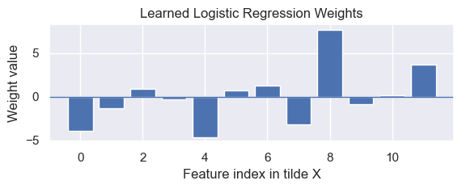

```python
# Visualize the weigths as a bar plot
### BEGIN SOLUTION
plt.figure(figsize=(6, 2.5))
plt.bar(np.arange(len(w_star)),np.asarray(w_star).flatten())
plt.title("Learned Logistic Regression Weights")
plt.xlabel("Feature index in tilde X")
plt.ylabel("Weight value")
plt.axhline(0, linewidth=1)
plt.tight_layout()
### END SOLUTION
```

**Task 4.6** Create a function that makes a hard prediction of whether the it is class 0 or 1. It should take the probabilities as input. and return 0 or 1 by thresholding at $p=0.5$. Save the predictions as integers in `y_est`.

```python
def predict(p, threshold=0.5):
    ### BEGIN SOLUTION
    y_est = (p >= threshold).astype(int)
    ### END SOLUTION
    return y_est

# Classify wine as White/Red (0/1) and assess probabilities
p_est = p_y_given_w_and_x(w_star, X_tilde, np.ones((X.shape[0],1)))
y_est = predict(p_est)
```

**Task 4.7:** What is visualized in the plot below?

- *Answer:*

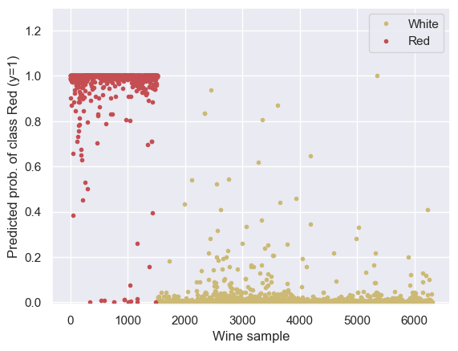

```python
plt.figure()
class0_ids = np.nonzero(y == 0)[0].tolist()
plt.plot(class0_ids, p_est[class0_ids], ".y")
class1_ids = np.nonzero(y == 1)[0].tolist()
plt.plot(class1_ids, p_est[class1_ids], ".r")
plt.xlabel("Wine sample")
plt.ylabel("Predicted prob. of class Red (y=1)")
plt.ylim(-0.01, 1.3)
plt.legend(["White", "Red"])
```

**Task 4.8:** Compute the error rate (aka the misclassificaiton rate), `error_rate`. How does this relate to the accuracy?

```python
# Evaluate the classifier's misclassification rate over entire training data
### BEGIN SOLUTION
error_rate = np.sum(y_est != y) / float(len(y_est))
### END SOLUTION

print("\nOverall misclassification rate: {0:.4f}".format(error_rate))
```

```
Overall misclassification rate: 0.0048
```

**Task 4.9:** Use the model to show that the following newly observed wine, would be classified as White wine. Do this by computing and save the probably of $p(y=1 \mid x, w)$ in `p_y_is_one_given_x_star` (i.e. the probability of a red wine).

- Fixed acidity: 6.9
- Volatile acidity: 1.09
- Citric acid: 0.06
- Residual sugar: 2.1
- Chlorides: 0.0061
- Free sulfur dioxide: 12.0
- Total sulfur dioxide: 31.0
- Density: 0.99
- pH: 3.5
- Sulphates: 0.44
- Alcohol: 12.0

> *Hint:* Use your function `p_y_given_w_and_x` and recall that we standardized the data!

```python
# Define the new wine, and evaluate its probability of being a red wine (i.e. y=1).
### BEGIN SOLUTION
x_star = np.array([[1, 6.9, 1.09, 0.06, 2.1, 0.0061, 12, 31, 0.99, 3.5, 0.44, 12]])
x_star[:, 1:] = (x_star[:, 1:] - mu.to_numpy())  / sig.to_numpy()  # std according to training data
p_y_is_one_given_x_star = p_y_given_w_and_x(w_star,x_star,1).item()
### END SOLUTION

print(f"Probability of given sample being a red wine: {p_y_is_one_given_x_star:.4f}")
```

```
Probability of given sample being a red wine: 0.0844
```

**Task 4.10:** Go back to where you defined your data. How does the following affect the performance of your logistic regression model?

- Adding a feature that is pure noise
- Adding a feature that is very similar to an existing one. E.g. do `X['new-pH'] = X['pH'] + 0.01 * np.random.randn(X.shape[0])`
- Removing some of the features
- Not standardization of the input features (Here you would need to run the naiive optimization function for much, much longer and check that you have converged; perhaps use the method in 4.11 to do this)

**Task 4.11 (optional)**: The toolbox sklearn has an convient implementaion of logistic regression, named `sklearn.linear_model.LogisticRegression`. You should use this for actual applications instead of our custom implementation.

Try to fit the model using `sklearn.linear_model.LogisticRegression`. Do you get the same result as when using our own rather naiive implementation?

> *Hint:* `LogisticRegression` is tempting to use “as is”, but it performs several steps under the hood (regularization, intercept handling, stopping criteria, solver choices) that can obscure what’s happening when you’re first learning the algorithm. To match the model defined above as closely as possible, use:

> `LogisticRegression(max_iter=1000, fit_intercept=False, tol=1e-6, C=np.inf)`

> We’ll explain the role of `C` (and its theoretical motivation) later in the course.

```
Norm: 11.154981934966482
```

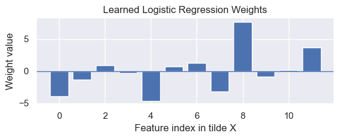

```python
# Fit the logistic regression model using sklearn
### BEGIN SOLUTION
from sklearn.datasets import load_iris
from sklearn.linear_model import LogisticRegression

# Fit the logistic regression model
model = LogisticRegression(max_iter=1000, fit_intercept=False,tol=1e-6,C=np.inf)
model = model.fit(X_tilde, y.ravel())
w_star_sklearn = model.coef_[0]
print(f"Norm: {np.linalg.norm(w_star_sklearn)}")

# Visualize the weigths as a bar plot
plt.figure(figsize=(6, 2.5))
plt.bar(np.arange(len(w_star_sklearn)),np.asarray(w_star_sklearn).flatten())
plt.title("Learned Logistic Regression Weights")
plt.xlabel("Feature index in tilde X")
plt.ylabel("Weight value")
plt.axhline(0, linewidth=1)
plt.tight_layout()
### END SOLUTION
```